# All Homework

# 8

## Exercise 8.3

The Count 5 test for equal variances in Section 6.4 is based on the maximum number of extreme points. Example 6.15 shows that the Count 5 criterion is not applicable for unequal sample sizes. Implement a permutation test for equal variance based on the maximum number of extreme points that applies when sample sizes are not necessarily equal.

### answer

```r
# define the function of "count five test"
count5test <- function(x, y) {
  X <- x - mean(x)
  Y <- y - mean(y)
  outx <- sum(X > max(Y)) + sum(X < min(Y))
  outy <- sum(Y > max(X)) + sum(Y < min(X))
  # get the statistic of "count five test"
  return(as.integer(max(c(outx, outy))))
}
```

```r
# get two samples with the same variance while sample sizes are not equal
set.seed(12345)
n1 <- 20
n2 <- 30
mu1 <- mu2 <- 0
sigma1 <- sigma2 <- 1
x <- rnorm(n1, mu1, sigma1)
y <- rnorm(n2, mu2, sigma2)
#centered by sample mean
x <- x - mean(x)
y <- y - mean(y)
```

```r
t0 <- count5test(x,y)
R <- 999 #number of replicates
z <- c(x, y) #pooled sample
K <- 1:(n1+n2)
reps <- numeric(R) #storage for replicates
for (i in 1:R) {
#generate indices k for the first sample
k <- sample(K, size = n1, replace = FALSE)
x1 <- z[k]
y1 <- z[-k] #complement of x1
reps[i] <- count5test(x1, y1)
}
# print the p-value
mean(reps > t0)
```

```
## [1] 0.1411411
```

## Dicussion

- Power comparison (distance correlation test versus ball covariance test)

  Model 1: $Y=X/4+e$  
  Model 2: $Y=X/4\times e$  
  $X\sim N(0_2,I_2)$, $e\sim N(0_2,I_2)$, $X$ and $e$ are independent.

### answer

```r
library(MASS)
library(Ball)
library(boot)

dCov <- function(x, y) {
  x <- as.matrix(x)
  y <- as.matrix(y)
  n <- nrow(x)
  m <- nrow(y)
  if (n != m || n < 2) stop("Sample sizes must agree")
  if (! (all(is.finite(c(x, y)))))
    stop("Data contains missing or infinite values")
  Akl <- function(x) {
    d <- as.matrix(dist(x))
    m <- rowMeans(d)
    M <- mean(d)
    a <- sweep(d, 1, m)
    b <- sweep(a, 2, m)
    return(b + M)
  }
  A <- Akl(x)
  B <- Akl(y)
  dCov <- sqrt(mean(A * B))
}

ndCov2 <- function(z, ix, dims) {
  #dims contains dimensions of x and y
  p <- dims[1]
  q1 <- dims[2] + 1
  d <- p + dims[2]
  x <- z[ , 1:p] #leave x as is
  y <- z[ix, -(1:p)] #permute rows of y
  return(nrow(z) * dCov(x, y)^2)
}

dc.test <- function(z, dims){
  boot.obj <- boot(data = z, statistic = ndCov2, R = R, sim = "permutation",  dims = c(2,2))
  ts <- c(boot.obj$t0,boot.obj$t)
  p.value <- mean(ts >= ts[1])
  list(statistic=ts[1], p.value=p.value)
}
```

```r
set.seed(12345)
m <- 100
u <- c(0,0)
sigma <- matrix(c(1,0,0,1), 2, 2)
R <- 1e2
alpha <- 0.1
n <- seq(10,100,10)
power.dc <- power.ball <- numeric(length(n))
p.dc <- p.ball <- numeric(m)
```

Model 1: Y = X/4 + e

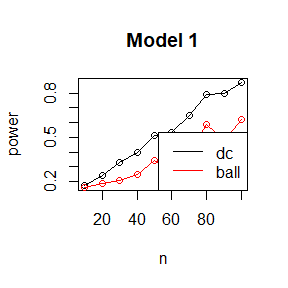

```r
for(j in 1:length(n)){
 for(i in 1:m){
    x<-matrix(rnorm(n[j]*2),nrow = n[j])
    e<-matrix(rnorm(n[j]*2),nrow = n[j])
    y <- x/4+e
    z <- as.data.frame(cbind(x,y))
    p.dc[i] <- dc.test(z, c(2,2))$p.value
    p.ball[i] <- bcov.test(x, y, R=R, seed = i*12345)$p.value
  }
  power.dc[j] <- mean(p.dc < alpha)
  power.ball[j] <- mean(p.ball < alpha)
}

# plot the power
plot(n, power.dc, type = "o", xlab = "n", ylab = "power", main = "Model 1", col = 1)
lines(n, power.ball, type = "o", col = 2)
legend('bottomright', legend = c('dc', 'ball'), col = 1:2, lty = 1)
```

Model 2: Y = X/4 * e

[figure not shown]

```r
for(j in 1:length(n)){
  for(i in 1:m){
    x<-matrix(rnorm(n[j]*2),nrow = n[j])
    e<-matrix(rnorm(n[j]*2),nrow = n[j])
    y <- x/4*e
    z <- as.data.frame(cbind(x,y))
    p.dc[i] <- dc.test(z, c(2,2))$p.value
    p.ball[i] <- bcov.test(x, y, R=R, seed = i*12345)$p.value
  }
  power.dc[j] <- mean(p.dc < alpha)
  power.ball[j] <- mean(p.ball < alpha)
}

# plot the power
plot(n, power.dc, type = "o", xlab = "n", ylab = "power", main = "Model 1", col = 1)
lines(n, power.ball, type = "o", col = 2)
legend('bottomright', legend = c('dc', 'ball'), col = 1:2, lty = 1)
```

As for model 1, “distance correlation test” would be better As for model 2, “ball covariance test” would be better.

# 9

## Exercise 9.4

Implement a random walk Metropolis sampler for generating the standard Laplace distribution (see Exercise 3.2). For the increment, simulate from a normal distribution. Compare the chains generated when different variances are used for the proposal distribution. Also, compute the acceptance rates of each chain.

### answer

The standard Laplace distribution has density $f(x) = \frac{1}{2}e^{-\left | x \right |}, x \in R$

```r
laplace <- function(x, mu = 0, lambda = 1){
  return(1/(2*lambda)*exp(-abs(x-mu)/lambda))
}

rw.Metropolis <- function(sigma, x0, N) {
  x <- numeric(N)
  x[1] <- x0
  u <- runif(N)
  k <- 0
  for (i in 2:N) {
    y <- rnorm(1, x[i-1], sigma)
    if (u[i] <= (laplace(y, 0, 1) / laplace(x[i-1], 0, 1)))
      x[i] <- y
    else {
        x[i] <- x[i-1]
        k <- k + 1
      }
  }
  return(list(x=x, k=k))
}

#par(mfrow = c(2,2))
N <- 2000
sigma <- c(.05, .5, 2, 16)
x0 <- 25
rw1 <- rw.Metropolis(sigma[1], x0, N)
rw2 <- rw.Metropolis(sigma[2], x0, N)
rw3 <- rw.Metropolis(sigma[3], x0, N)
rw4 <- rw.Metropolis(sigma[4], x0, N)
#number of candidate points rejected
accept <- 1-c(rw1$k, rw2$k, rw3$k, rw4$k)/N
print(accept)
```

```
## [1] 0.9830 0.8145 0.5280 0.1105
```

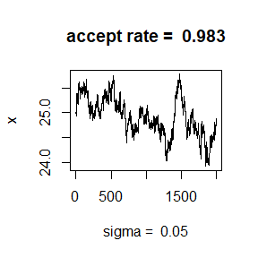

```r
plot(rw1$x, type="l", main = paste("accept rate = ",accept[1]), xlab = paste("sigma = ",sigma[1]), ylab = "x")
abline(h = c(log(0.05/2), -log(0.05/2)), col = "red")
```

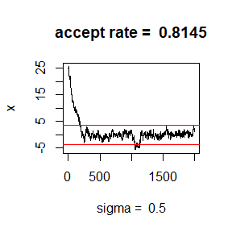

```r
plot(rw2$x, type="l", main = paste("accept rate = ",accept[2]), xlab = paste("sigma = ",sigma[2]), ylab = "x")
abline(h = c(log(0.05/2), -log(0.05/2)), col = "red")
```

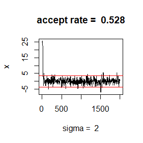

```r
plot(rw3$x, type="l", main = paste("accept rate = ",accept[3]), xlab = paste("sigma = ",sigma[3]), ylab = "x")
abline(h = c(log(0.05/2), -log(0.05/2)), col = "red")
```

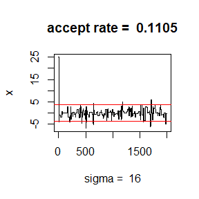

```r
plot(rw4$x, type="l", main = paste("accept rate = ",accept[4]), xlab = paste("sigma = ",sigma[4]), ylab = "x")
abline(h = c(log(0.05/2), -log(0.05/2)), col = "red")
```

In the first plot of Figure with $\sigma = 0.05$, the ratios $r(X_t,Y)$ tend to be large and almost every candidate point is accepted. The increments are small and the chain is almost like a true random walk. Chain 1 has not converged to the target in 2000 iterations. The chain in the second plot generated with $\sigma = 0.5$ is converging little slowly, and very few points are rejected. In the third plot $\sigma = 2$ the chain is mixing well and converging to the target distribution after a short burn-in period of about 50. Finally, in the fourth plot, where $\sigma = 16$, the ratios $r(X_t,Y)$ are smaller and most of the candidate points are rejected. The fourth chain converges, but it is inefficient.

# 10

## Exercises 11.1

The natural logarithm and exponential functions are inverses of each other, so that mathematically log(exp x) = exp(log x) = x. Show by example that this property does not hold exactly in computer arithmetic. Does the identity hold with near equality? (See all.equal.)

### answer

```r
x <- 1000
log(exp(x)) == exp(log(x))
```

```
## [1] FALSE
```

```r
isTRUE(all.equal(log(exp(x)), exp(log(x))))
```

```
## [1] FALSE
```

## Exercises 11.5

Write a function to solve the equation $\frac{2\Gamma (\frac{k}{2})}{\sqrt{\pi(k-1)}\Gamma(\frac{k-1}{2})}\int_{0}^{c_{k-1}}(1+\frac{u^2}{k-1})^{-k/2}du$ = $\frac{2\Gamma (\frac{k+1}{2})}{\sqrt{\pi k}\Gamma (\frac{k}{2})}\int_{0}^{c_k}(1+\frac{u^2}{k})^{-(k+1)/2}du$ for a, where $c_k = \sqrt{\frac{a^2 k}{k+1-a^2}}$ compare the solutions with the points A(k) in Exercise 11.4

### answer

Exercise 11.4 Find the intersection points A(k) in (0, $\sqrt{k}$) of the curves $S_{k-1}(a) = P(t(k-1) > \sqrt{\frac{a^2(k-1)}{k-a^2}})$ and $S_{k}(a) = P(t(k) > \sqrt{\frac{a^2(k)}{k+1-a^2}})$ for k = 4 : 25, 100, 500, 1000, where t(k) is a Student t random variable with k degrees of freedom. (These intersection points determine the critical values for a t-test for scale-mixture errors proposed by Szekely [260].)

The solution of exercise 11.4 as followed:

```r
k <- c(4:25, 100, 500, 1000)
r1 <- rep(0,length(k))
for(i in 1:length(k)){
  ki <- k[i]
  ck <- function(a, ki){
    sqrt(a^2*ki/(ki+1-a^2))
  }

  s <- function(a, ki){
    pt(ck(a, ki), df=ki) - pt(ck(a, ki-1), df=ki-1)
  }

  f <- function(a){
    return(s(a,ki))
  }
  r1[i] <- uniroot(f, lower = 1e-6, upper = sqrt(ki)-1e-6)$root
}
r1
```

```
##  [1]  1.492103  1.533549  1.562768  1.584421  1.601182  1.614517  1.625406
##  [8]  1.634409  1.642026  1.648511  1.654174  1.659121  1.663442  1.667288
## [15]  1.670736  1.673841  1.676589  1.679139  1.681461  4.795831  4.898978
## [22]  4.999999  9.999999 22.360679 31.622776
```

solution for exercise 11.5

```r
k <- c(4:25)
r2 <- rep(0,length(k))
for(i in 1:length(k)){
  ki <- k[i]

  h <- function(a, ki){
    ck <- function(a, ki){
       sqrt(a^2*ki/(ki+1-a^2))
    }

    g <- function(u){
      (1+u^2/ki)^(-(ki+1)/2)
    }

    # for simplily, get the log of the function
    r<-lgamma((ki+1)/2)-log(sqrt(pi*ki))-lgamma(ki/2)+log(integrate(g, lower = 0, upper=ck(a,ki), rel.tol=.Machine$double.eps^0.25)$value)
    return(r)
  }

  f <- function(a){
    h(a, ki) - h(a, ki-1)
  }
  r2[i] <- uniroot(f, lower = 1e-7, upper = sqrt(ki)-0.15)$root
}
r2
```

```
##  [1] 1.492076 1.533559 1.562747 1.584429 1.601182 1.614519 1.625385 1.634409
##  [9] 1.642054 1.648568 1.654176 1.659104 1.663454 1.667267 1.670724 1.673818
## [17] 1.676614 1.679154 1.681490 1.683572 1.685538 1.687346
```

```r
ki <- 100
r3 <- uniroot(f, lower = 1e-7, upper = sqrt(ki)-3)$root
r3
```

```
## [1] 1.720575
```

```r
ki <- 500
r4 <- uniroot(f, lower = 1e-7, upper = sqrt(ki)-20)$root
r4
```

```
## [1] 1.729747
```

```r
ki <- 1000
r5 <- uniroot(f, lower = 1e-7, upper = sqrt(ki)-26)$root
r5
```

```
## [1] 1.730895
```

Compare with the result in 11.4, can find that the solution are near equal when k is small such as from 4 to 20, but when k is lager enough, the result is not good.

## A-B-O blood type problem

- Let the three alleles be A, B, and O with allele frequencies p, q, and r. The 6 genotype frequencies under HWE and complete counts are as follows.
  - Observed data: $n_{A\cdot}=n_{AA}+n_{AO}=28$ (A-type), $n_{B\cdot}=n_{BB}+n_{BO}=24$ (B-type), $n_{OO}=41$ (O-type), $n_{AB}=70$ (AB-type).
  - Use EM algorithm to solve MLE of $p$ and $q$ (consider missing data $n_{AA}$ and $n_{BB}$).
  - Record the log-maximum likelihood values in M-steps, are they increasing?

### answer

```r
# define the function to compute n!
pro <- function(n){
  if(n<0)
    print("warning: your input is wrong!")
  else if(n==0)
    print(1)
  else {
    s <- length(n)
    s[1] <- 1
    for(i in 2:n){
      s[i] <- i*s[i-1]
    }
    return(s[n])
  }
}
```

```r
# Use EM algorithm to solve MLE of p and q
blood <- function(P, n.obs){
  n <- sum(n.obs)
  na <- n.obs[1]
  nb <- n.obs[2]
  nab <- n.obs[3]
  no <- n.obs[4]
  noo <- no

  ## E step
#  cat(P, "\n")  # P is the vector of original probability c(p,q,r)
  p <- q <- r <- rep(0, m)
  lnf <- rep(0, m-1)
  p[1] <- P[1]
  q[1] <- P[2]
  r[1] <- 1 - P[1] - P[2]
  for(i in 2:m){
    # instead old value by new value
    p.old <- p[i-1]
    q.old <- q[i-1]
    r.old <- r[i-1]

    ## M step
    den1 <- p.old^2 + 2 * p.old * r.old
    naa <- na * p.old^2 / den1
    nao <- 2 * na * p.old * r.old / den1
    den2 <- q.old^2 + 2 * q.old * r.old
    nbb <- nb * q.old^2 / den2
    nbo <- 2 * nb * q.old * r.old / den2
    p[i] <- (2*naa + nao + nab)/(2*n)
    q[i] <- (2*nbb + nbo + nab)/(2*n)
    r[i] <- (2*noo + nao + nbo)/(2*n)
    lnf[i-1] <- naa*log(p[i]^2)+nao*log(2*p[i]*r[i])+nbb*log(q[i]^2)+nbo*log(2*q[i]*r[i])+nab*log(p[i]*q[i])+noo*log(r[i]^2)+log(pro(n)/(pro(naa)*pro(nao)*pro(nbb)*pro(nbo)*pro(nab)*pro(noo)))
  }

  return(list(P = c(p[m], q[m], r[m]), lh = lnf[1:50]))  # return the first 50 values
}
n.obs <- c(28, 24, 70, 41)
m <- 1000 #repicate times
P <- c(1/3, 1/3)  # set the original value

c <- blood(P, n.obs)
c$P
```

```
## [1] 0.3273442 0.3104267 0.3622291
```

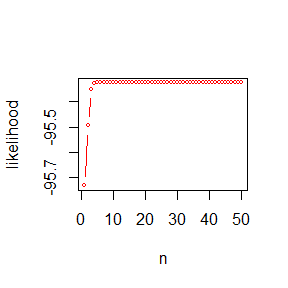

```r
#c$lh
plot(c$lh, xlab="n", ylab="likelihood", type="b", cex=.5, col=2)
```

# 11

## Exercise 3 (P204)

Use both for loops and lapply() to fit linear models to the mtcars using the formulas stored in this list:  
formulas <- list(  
mpg ~ disp,  
mpg ~ I(1 / disp),  
mpg ~ disp + wt,  
mpg ~ I(1 / disp) + wt  
)

### answer

```r
formulas <- list(
  mpg ~ disp,
  mpg ~ I(1 / disp),
  mpg ~ disp + wt,
  mpg ~ I(1 / disp) + wt
)

# use for loops
r1 <- list()
for (i in 1:4){
  r1[[i]]  <- lm(formula = formulas[[i]], data = mtcars)
}
r1
```

```
## [[1]]
##
## Call:
## lm(formula = formulas[[i]], data = mtcars)
##
## Coefficients:
## (Intercept)         disp
##    29.59985     -0.04122
##
##
## [[2]]
##
## Call:
## lm(formula = formulas[[i]], data = mtcars)
##
## Coefficients:
## (Intercept)    I(1/disp)
##       10.75      1557.67
##
##
## [[3]]
##
## Call:
## lm(formula = formulas[[i]], data = mtcars)
##
## Coefficients:
## (Intercept)         disp           wt
##    34.96055     -0.01772     -3.35083
##
##
## [[4]]
##
## Call:
## lm(formula = formulas[[i]], data = mtcars)
##
## Coefficients:
## (Intercept)    I(1/disp)           wt
##      19.024     1142.560       -1.798
```

```r
# use lapply()
r2 <- lapply(formulas, function(formulas){
  lm(formula = formulas, data = mtcars)
})
r2
```

```
## [[1]]
##
## Call:
## lm(formula = formulas, data = mtcars)
##
## Coefficients:
## (Intercept)         disp
##    29.59985     -0.04122
##
##
## [[2]]
##
## Call:
## lm(formula = formulas, data = mtcars)
##
## Coefficients:
## (Intercept)    I(1/disp)
##       10.75      1557.67
##
##
## [[3]]
##
## Call:
## lm(formula = formulas, data = mtcars)
##
## Coefficients:
## (Intercept)         disp           wt
##    34.96055     -0.01772     -3.35083
##
##
## [[4]]
##
## Call:
## lm(formula = formulas, data = mtcars)
##
## Coefficients:
## (Intercept)    I(1/disp)           wt
##      19.024     1142.560       -1.798
```

Results by using for loops and lapply are same.

## Exercise 4 (P204)

Fit the model mpg ~ disp to each of the bootstrap replicates of mtcars in the list below by using a for loop and lapply(). Can you do it without an anonymous function?

### answer

```r
bootstraps <- lapply(1:10, function(i) {
  rows <- sample(1: nrow(mtcars), rep = TRUE)
  mtcars[rows, ]
})

# use for loops
r3 <- list()
for (i in 1:10){
r3[[i]] <- lm(formula = mpg ~ disp, data = bootstraps[[i]])
}
r3
```

```
## [[1]]
##
## Call:
## lm(formula = mpg ~ disp, data = bootstraps[[i]])
##
## Coefficients:
## (Intercept)         disp
##    28.34891     -0.03979
##
##
## [[2]]
##
## Call:
## lm(formula = mpg ~ disp, data = bootstraps[[i]])
##
## Coefficients:
## (Intercept)         disp
##      29.941       -0.043
##
##
## [[3]]
##
## Call:
## lm(formula = mpg ~ disp, data = bootstraps[[i]])
##
## Coefficients:
## (Intercept)         disp
##     28.5716      -0.0415
##
##
## [[4]]
##
## Call:
## lm(formula = mpg ~ disp, data = bootstraps[[i]])
##
## Coefficients:
## (Intercept)         disp
##    27.41031     -0.03424
##
##
```

[output cut: 43 more lines]

```
## lm(formula = mpg ~ disp, data = bootstraps[[i]])
##
## Coefficients:
## (Intercept)         disp
##    26.41999     -0.03302
##
##
## [[10]]
##
## Call:
## lm(formula = mpg ~ disp, data = bootstraps[[i]])
##
## Coefficients:
## (Intercept)         disp
##    30.38313     -0.04404
```

```r
# use lapply
r4 <- lapply(bootstraps, function(x) lm(formula = mpg ~ disp, data = x))
r4
```

```
## [[1]]
##
## Call:
## lm(formula = mpg ~ disp, data = x)
##
## Coefficients:
## (Intercept)         disp
##    28.34891     -0.03979
##
##
## [[2]]
##
## Call:
## lm(formula = mpg ~ disp, data = x)
##
## Coefficients:
## (Intercept)         disp
##      29.941       -0.043
##
##
## [[3]]
##
## Call:
## lm(formula = mpg ~ disp, data = x)
##
## Coefficients:
## (Intercept)         disp
##     28.5716      -0.0415
##
##
## [[4]]
##
## Call:
## lm(formula = mpg ~ disp, data = x)
##
## Coefficients:
## (Intercept)         disp
##    27.41031     -0.03424
##
##
```

[output cut: 43 more lines]

```
## lm(formula = mpg ~ disp, data = x)
##
## Coefficients:
## (Intercept)         disp
##    26.41999     -0.03302
##
##
## [[10]]
##
## Call:
## lm(formula = mpg ~ disp, data = x)
##
## Coefficients:
## (Intercept)         disp
##    30.38313     -0.04404
```

Results by using two methods are same.

## Exercise 5 (P204)

For each model in the previous two exercises, extract R2 using the function below.  
rsq <- function(mod) summary(mod)$r.squared

### answer

```r
rsq <- function(mod) summary(mod)$r.squared
R1 <- lapply(r1, rsq)
R1
```

```
## [[1]]
## [1] 0.7183433
##
## [[2]]
## [1] 0.8596865
##
## [[3]]
## [1] 0.7809306
##
## [[4]]
## [1] 0.8838038
```

```r
R2 <- lapply(r2, rsq)
R2
```

```
## [[1]]
## [1] 0.7183433
##
## [[2]]
## [1] 0.8596865
##
## [[3]]
## [1] 0.7809306
##
## [[4]]
## [1] 0.8838038
```

```r
R3 <- lapply(r3, rsq)
R3
```

```
## [[1]]
## [1] 0.8318015
##
## [[2]]
## [1] 0.7579137
##
## [[3]]
## [1] 0.7997845
##
## [[4]]
## [1] 0.5636278
##
## [[5]]
## [1] 0.7332603
##
## [[6]]
## [1] 0.7086225
##
## [[7]]
## [1] 0.7622925
##
## [[8]]
## [1] 0.8105539
##
## [[9]]
## [1] 0.7108513
##
## [[10]]
## [1] 0.6902462
```

```r
R4 <- lapply(r4, rsq)
R4
```

```
## [[1]]
## [1] 0.8318015
##
## [[2]]
## [1] 0.7579137
##
## [[3]]
## [1] 0.7997845
##
## [[4]]
## [1] 0.5636278
##
## [[5]]
## [1] 0.7332603
##
## [[6]]
## [1] 0.7086225
##
## [[7]]
## [1] 0.7622925
##
## [[8]]
## [1] 0.8105539
##
## [[9]]
## [1] 0.7108513
##
## [[10]]
## [1] 0.6902462
```

## Exercise 3 (P214)

The following code simulates the performance of a t-test for non-normal data. Use sapply() and an anonymous function to extract the p-value from every trial.  
trials <- replicate(100, t.test(rpois(10, 10), rpois(7, 10)), simplify = FALSE)  
Extra challenge: get rid of the anonymous function by using [[ directly.

### answer

```r
trials <- replicate(100, t.test(rpois(10, 10), rpois(7, 10)), simplify = FALSE)
# use sapply
p1 <- sapply(trials, function(x) x$p.value)
p1
```

```
##   [1] 0.177553389 0.645900556 0.405204448 0.261542040 0.395000063 0.511295100
##   [7] 0.731726676 0.292777824 0.279296117 0.917575793 0.127791373 0.612046878
##  [13] 0.119924862 0.885400781 0.180010105 0.292632405 0.155923001 0.374152836
##  [19] 0.301010540 0.810104750 0.231392231 0.673027227 0.018326792 0.804004091
##  [25] 0.635468120 0.749321604 0.707371452 0.272922687 0.257012757 0.087843270
##  [31] 0.426785019 0.396809377 0.096857103 0.246896998 0.212570064 0.340915631
##  [37] 0.128589601 0.908053478 0.473965895 0.635159601 0.542049473 0.628098014
##  [43] 0.290575053 0.379755942 0.425396254 0.109022541 0.765262549 0.029318152
##  [49] 0.161142391 0.648351139 0.006866725 0.320098094 0.641822042 0.977959796
##  [55] 0.317714277 0.122085392 0.348221595 0.003914280 0.323871502 0.847691966
##  [61] 0.664879338 0.169666489 0.114353739 0.753354454 0.727444562 0.591625052
##  [67] 0.229431859 0.657560384 0.846588358 0.799557049 0.242671690 0.100014756
##  [73] 0.661402291 0.084518245 0.076414974 0.268952858 0.152859227 0.405693778
##  [79] 0.634904528 0.140875668 0.779453011 0.682896089 0.714919015 0.542484597
##  [85] 0.520081039 0.637485317 0.646642429 0.259043200 0.190740394 0.084319668
##  [91] 0.602544215 0.596269215 0.271421976 0.373611901 0.676898787 0.236010025
##  [97] 0.337512821 0.161442372 0.905386179 0.826823753
```

```r
# use for loops
p2 <- numeric(100)
for (i in 1:100){
p2[i] <- trials[[i]]$p.value
}
```

## Exercise 7 (P214)

Implement mcsapply(), a multicore version of sapply(). Can you implement mcvapply(), a parallel version of vapply()? Why or why not?

### answer

```r
library(parallel)
f <- function(x) c(sum(x), mean(x), sd(x))
x <- list(1:10, c(2,3,4), c(TRUE,FALSE,TRUE,TRUE))

# use mcsapply
mcsapply <- function(x, f){
  cl <- makeCluster(4)
  result <- parLapply(cl, x, f)
  stopCluster(cl)
  return(unlist(result))
}
# print the system.time
system.time(mcsapply(x, f))
```

```
## 用户 系统 流逝
## 0.00 0.03 0.97
```

```r
# use mcvapply
mcvapply <- function(x, f){
  cl <- makeCluster(4)
  result <- vapply(x,f,c("a" = 0, "b" = 0, "c" = 0))
  stopCluster(cl)
  return(result)
}
# print the system.time
system.time(mcvapply(x, f))
```

```
## 用户 系统 流逝
## 0.00 0.02 0.96
```

# 12

## Exercise

You have already written an R function for Exercise 9.4 (page 277, Statistical Computing with R). Rewrite an Rcpp function for the same task. * Compare the generated random numbers by the two functions using qqplot. * Campare the computation time of the two functions with microbenchmark. * Comments your results.

### answer

The standard Laplace distribution has density $f(x) = \frac{1}{2}e^{-\left | x \right |}, x \in R$

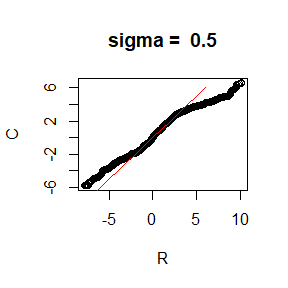

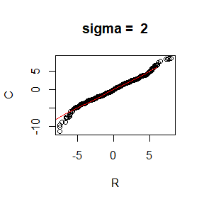

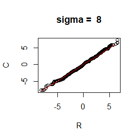

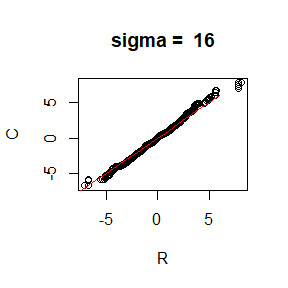

```r
# R function

laplace <- function(x, mu = 0, lambda = 1){
  return(1/(2*lambda)*exp(-abs(x-mu)/lambda))
}

rw <- function(sigma, x0, N) {
  x <- numeric(N)
  x[1] <- x0
  u <- runif(N)
  k <- 0
  for (i in 2:N) {
    y <- rnorm(1, x[i-1], sigma)
    if (u[i] <= (laplace(y, 0, 1) / laplace(x[i-1], 0, 1)))
      x[i] <- y
    else {
        x[i] <- x[i-1]
        k <- k + 1
      }
  }
  return(x)
}


# Cpp function
library(microbenchmark)
library(SC19037)
# define variables
N <- 10000
sigma <- c(0.5, 2, 8, 16)
x0 <- 5
#par(mfrow = c(2,2))
for (i in 1:4){
  # qqplot:
  r <- rw(sigma[i],x0,N)
  R <- as.vector(r)
  C <- rwC(sigma[i],x0,N)
  qqplot(R,C, main = paste("sigma = ",sigma[i]))
  points(x=seq(-8,6), y=seq(-8,6), type = "l", col = "red")
}
```

```r
for (i in 1:4){
  # compare two function:
  ts <- microbenchmark(R=rw(sigma[i],x0,N), Cpp=rwC(sigma[i],x0,N))
  print(summary(ts)[,c(1,3,5,6)])
}
```

```
##   expr       lq   median       uq
## 1    R 33.53915 35.27030 37.49215
## 2  Cpp  1.18190  1.22855  1.31590
##   expr       lq   median       uq
## 1    R 32.52965 33.57685 34.47195
## 2  Cpp  1.34645  1.41170  1.47900
##   expr      lq   median      uq
## 1    R 32.3198 33.60720 34.5076
## 2  Cpp  1.3670  1.41245  1.4790
##   expr       lq   median       uq
## 1    R 32.88905 33.83355 34.69115
## 2  Cpp  1.39290  1.44990  1.49065
```

From the above, we can find that the result of R and Cpp function are almost same, but the computition cost of R is more expensive, so if it is possible, we’d better to choose Cpp function to solve the question.